# Optimal Treatment Analysis

## Outcome Variable

**Outcome Variable:** haz

## Predictor Variables

**Intervention Variable:** impfloor

**Adjustment Set:**

- arm
- sex
- W_mage
- meducyrs
- feducyrs
- hhwealth_quart
- hfoodsec
- W_mhtcm
- W_mwtkg
- W_mbmi
- W_nrooms
- W_nchldlt5
- W_parity
- impsan
- safeh20
- delta_W_mage
- delta_meducyrs
- delta_feducyrs
- delta_hhwealth_quart
- delta_hfoodsec
- delta_W_mhtcm
- delta_W_mwtkg
- delta_W_mbmi
- delta_W_nrooms
- delta_W_nchldlt5
- delta_W_parity
- delta_impsan
- delta_safeh20

## Stratifying Variables

The analysis was stratified on these variable(s):

- agecat
- studyid
- country

## Data Summary

| agecat | studyid | country | impfloor | n_cell | n |
| --- | --- | --- | --- | --- | --- |
| Birth | ki0047075b-MAL-ED | BANGLADESH | 1 | 196 | 213 |
| Birth | ki0047075b-MAL-ED | BANGLADESH | 0 | 17 | 213 |
| Birth | ki0047075b-MAL-ED | BRAZIL | 1 | 58 | 60 |
| Birth | ki0047075b-MAL-ED | BRAZIL | 0 | 2 | 60 |
| Birth | ki0047075b-MAL-ED | INDIA | 1 | 35 | 41 |
| Birth | ki0047075b-MAL-ED | INDIA | 0 | 6 | 41 |
| Birth | ki0047075b-MAL-ED | NEPAL | 1 | 9 | 25 |
| Birth | ki0047075b-MAL-ED | NEPAL | 0 | 16 | 25 |
| Birth | ki0047075b-MAL-ED | PERU | 1 | 39 | 215 |
| Birth | ki0047075b-MAL-ED | PERU | 0 | 176 | 215 |
| Birth | ki0047075b-MAL-ED | SOUTH AFRICA | 1 | 87 | 96 |
| Birth | ki0047075b-MAL-ED | SOUTH AFRICA | 0 | 9 | 96 |
| Birth | ki0047075b-MAL-ED | TANZANIA, UNITED REPUBLIC OF | 1 | 7 | 119 |
| Birth | ki0047075b-MAL-ED | TANZANIA, UNITED REPUBLIC OF | 0 | 112 | 119 |
| Birth | ki1000108-CMC-V-BCS-2002 | INDIA | 1 | 72 | 72 |
| Birth | ki1000108-CMC-V-BCS-2002 | INDIA | 0 | 0 | 72 |
| Birth | ki1000108-IRC | INDIA | 1 | 287 | 287 |
| Birth | ki1000108-IRC | INDIA | 0 | 0 | 287 |
| Birth | ki1017093-NIH-Birth | BANGLADESH | 1 | 533 | 605 |
| Birth | ki1017093-NIH-Birth | BANGLADESH | 0 | 72 | 605 |
| Birth | ki1017093b-PROVIDE | BANGLADESH | 1 | 491 | 539 |
| Birth | ki1017093b-PROVIDE | BANGLADESH | 0 | 48 | 539 |
| Birth | ki1017093c-NIH-Crypto | BANGLADESH | 1 | 558 | 732 |
| Birth | ki1017093c-NIH-Crypto | BANGLADESH | 0 | 174 | 732 |
| Birth | ki1113344-GMS-Nepal | NEPAL | 1 | 100 | 544 |
| Birth | ki1113344-GMS-Nepal | NEPAL | 0 | 444 | 544 |
| Birth | ki1114097-CONTENT | PERU | 1 | 2 | 2 |
| Birth | ki1114097-CONTENT | PERU | 0 | 0 | 2 |
| Birth | kiGH5241-JiVitA-3 | BANGLADESH | 1 | 1394 | 22399 |
| Birth | kiGH5241-JiVitA-3 | BANGLADESH | 0 | 21005 | 22399 |

[output cut: 66 more lines]

The following strata were considered:

- agecat: 24 months, studyid: ki0047075b-MAL-ED, country: BANGLADESH
- agecat: 24 months, studyid: ki0047075b-MAL-ED, country: BRAZIL
- agecat: 24 months, studyid: ki0047075b-MAL-ED, country: INDIA
- agecat: 24 months, studyid: ki0047075b-MAL-ED, country: NEPAL
- agecat: 24 months, studyid: ki0047075b-MAL-ED, country: PERU
- agecat: 24 months, studyid: ki0047075b-MAL-ED, country: SOUTH AFRICA
- agecat: 24 months, studyid: ki0047075b-MAL-ED, country: TANZANIA, UNITED REPUBLIC OF
- agecat: 24 months, studyid: ki1000108-CMC-V-BCS-2002, country: INDIA
- agecat: 24 months, studyid: ki1000108-IRC, country: INDIA
- agecat: 24 months, studyid: ki1017093-NIH-Birth, country: BANGLADESH
- agecat: 24 months, studyid: ki1017093b-PROVIDE, country: BANGLADESH
- agecat: 24 months, studyid: ki1017093c-NIH-Crypto, country: BANGLADESH
- agecat: 24 months, studyid: ki1113344-GMS-Nepal, country: NEPAL
- agecat: 24 months, studyid: ki1114097-CONTENT, country: PERU
- agecat: 24 months, studyid: kiGH5241-JiVitA-3, country: BANGLADESH
- agecat: 24 months, studyid: kiGH5241-JiVitA-4, country: BANGLADESH
- agecat: 6 months, studyid: ki0047075b-MAL-ED, country: BANGLADESH
- agecat: 6 months, studyid: ki0047075b-MAL-ED, country: BRAZIL
- agecat: 6 months, studyid: ki0047075b-MAL-ED, country: INDIA
- agecat: 6 months, studyid: ki0047075b-MAL-ED, country: NEPAL
- agecat: 6 months, studyid: ki0047075b-MAL-ED, country: PERU
- agecat: 6 months, studyid: ki0047075b-MAL-ED, country: SOUTH AFRICA
- agecat: 6 months, studyid: ki0047075b-MAL-ED, country: TANZANIA, UNITED REPUBLIC OF
- agecat: 6 months, studyid: ki1000108-CMC-V-BCS-2002, country: INDIA
- agecat: 6 months, studyid: ki1000108-IRC, country: INDIA
- agecat: 6 months, studyid: ki1017093-NIH-Birth, country: BANGLADESH
- agecat: 6 months, studyid: ki1017093b-PROVIDE, country: BANGLADESH
- agecat: 6 months, studyid: ki1017093c-NIH-Crypto, country: BANGLADESH
- agecat: 6 months, studyid: ki1113344-GMS-Nepal, country: NEPAL
- agecat: 6 months, studyid: ki1114097-CONTENT, country: PERU
- agecat: 6 months, studyid: kiGH5241-JiVitA-3, country: BANGLADESH
- agecat: 6 months, studyid: kiGH5241-JiVitA-4, country: BANGLADESH
- agecat: Birth, studyid: ki0047075b-MAL-ED, country: BANGLADESH
- agecat: Birth, studyid: ki0047075b-MAL-ED, country: BRAZIL
- agecat: Birth, studyid: ki0047075b-MAL-ED, country: INDIA
- agecat: Birth, studyid: ki0047075b-MAL-ED, country: NEPAL
- agecat: Birth, studyid: ki0047075b-MAL-ED, country: PERU
- agecat: Birth, studyid: ki0047075b-MAL-ED, country: SOUTH AFRICA
- agecat: Birth, studyid: ki0047075b-MAL-ED, country: TANZANIA, UNITED REPUBLIC OF
- agecat: Birth, studyid: ki1000108-CMC-V-BCS-2002, country: INDIA
- agecat: Birth, studyid: ki1000108-IRC, country: INDIA
- agecat: Birth, studyid: ki1017093-NIH-Birth, country: BANGLADESH
- agecat: Birth, studyid: ki1017093b-PROVIDE, country: BANGLADESH
- agecat: Birth, studyid: ki1017093c-NIH-Crypto, country: BANGLADESH
- agecat: Birth, studyid: ki1113344-GMS-Nepal, country: NEPAL
- agecat: Birth, studyid: ki1114097-CONTENT, country: PERU
- agecat: Birth, studyid: kiGH5241-JiVitA-3, country: BANGLADESH
- agecat: Birth, studyid: kiGH5241-JiVitA-4, country: BANGLADESH

### Dropped Strata

Some strata were dropped due to rare outcomes:

- agecat: Birth, studyid: ki0047075b-MAL-ED, country: BRAZIL
- agecat: Birth, studyid: ki1000108-CMC-V-BCS-2002, country: INDIA
- agecat: Birth, studyid: ki1000108-IRC, country: INDIA
- agecat: Birth, studyid: ki1114097-CONTENT, country: PERU
- agecat: 6 months, studyid: ki0047075b-MAL-ED, country: BRAZIL
- agecat: 6 months, studyid: ki1000108-CMC-V-BCS-2002, country: INDIA
- agecat: 6 months, studyid: ki1000108-IRC, country: INDIA
- agecat: 24 months, studyid: ki0047075b-MAL-ED, country: BRAZIL
- agecat: 24 months, studyid: ki1000108-CMC-V-BCS-2002, country: INDIA
- agecat: 24 months, studyid: ki1000108-IRC, country: INDIA

## Methods Detail

We’re interested in the causal parameters $E[Y_a]$ for all values of $a \in \mathcal{A}$. These parameters represent the mean outcome if, possibly contrary to fact, we intervened to set all units to have $A=a$. Under the randomization and positivity assumptions, these are identified by the statistical parameters $\psi_a=E_W[E_{Y|A,W}(Y|A=a,W)]$. In addition, we’re interested in the mean of $Y$, $E[Y]$ under no intervention (the observed mean). We will estimate these parameters by using SuperLearner to fit the relevant likelihood factors – $E_{Y|A,W}(Y|A=a,W)$ and $p(A=a|W)$, and then updating our likelihood fit using a joint TMLE.

For unadjusted analyses ($W=\{\}$), initial likelihoods were estimated using Lrnr_glm to estimate the simple $E(Y|A)$ and Lrnr_mean to estimate $p(A)$. For adjusted analyses, a small library containing Lrnr_glmnet, Lrnr_xgboost, and Lrnr_mean was used.

Having estimated these parameters, we will then use the delta method to estimate relative risks and attributable risks relative to a prespecified baseline level of $A$.

# Results Detail

## Results Plots

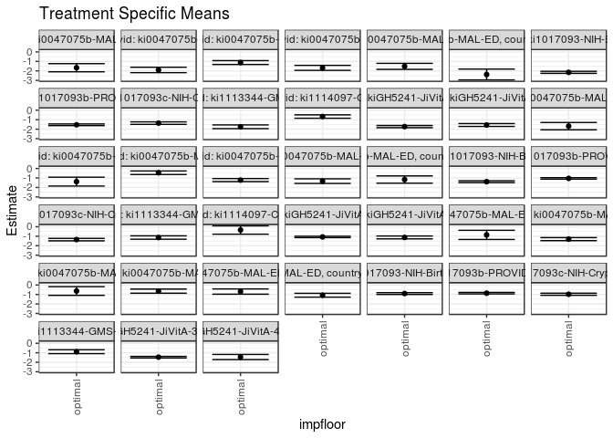

## Results Table

### Parameter: TSM

| agecat | studyid | country | intervention_level | baseline_level | estimate | ci_lower | ci_upper |
| --- | --- | --- | --- | --- | --- | --- | --- |
| Birth | ki0047075b-MAL-ED | BANGLADESH | optimal | observed | -0.8598505 | -1.3437379 | -0.3759631 |
| Birth | ki0047075b-MAL-ED | INDIA | optimal | observed | -1.3060428 | -1.4660759 | -1.1460097 |
| Birth | ki0047075b-MAL-ED | NEPAL | optimal | observed | -0.6316672 | -1.0894038 | -0.1739307 |
| Birth | ki0047075b-MAL-ED | PERU | optimal | observed | -0.6472733 | -0.8662102 | -0.4283363 |
| Birth | ki0047075b-MAL-ED | SOUTH AFRICA | optimal | observed | -0.6901557 | -0.9671147 | -0.4131968 |
| Birth | ki0047075b-MAL-ED | TANZANIA, UNITED REPUBLIC OF | optimal | observed | -1.0777242 | -1.2791671 | -0.8762813 |
| Birth | ki1017093-NIH-Birth | BANGLADESH | optimal | observed | -0.8973222 | -0.9924817 | -0.8021627 |
| Birth | ki1017093b-PROVIDE | BANGLADESH | optimal | observed | -0.8618234 | -0.9407917 | -0.7828551 |
| Birth | ki1017093c-NIH-Crypto | BANGLADESH | optimal | observed | -0.9758238 | -1.0857816 | -0.8658660 |
| Birth | ki1113344-GMS-Nepal | NEPAL | optimal | observed | -0.8884190 | -1.0937086 | -0.6831294 |
| Birth | kiGH5241-JiVitA-3 | BANGLADESH | optimal | observed | -1.4625132 | -1.5450452 | -1.3799812 |
| Birth | kiGH5241-JiVitA-4 | BANGLADESH | optimal | observed | -1.4472926 | -1.7184147 | -1.1761705 |
| 6 months | ki0047075b-MAL-ED | BANGLADESH | optimal | observed | -1.6791142 | -2.0638040 | -1.2944244 |
| 6 months | ki0047075b-MAL-ED | INDIA | optimal | observed | -1.3870396 | -1.8558639 | -0.9182154 |
| 6 months | ki0047075b-MAL-ED | NEPAL | optimal | observed | -0.4504224 | -0.6382575 | -0.2625874 |
| 6 months | ki0047075b-MAL-ED | PERU | optimal | observed | -1.2239752 | -1.3833670 | -1.0645835 |
| 6 months | ki0047075b-MAL-ED | SOUTH AFRICA | optimal | observed | -1.3335028 | -1.5763833 | -1.0906224 |
| 6 months | ki0047075b-MAL-ED | TANZANIA, UNITED REPUBLIC OF | optimal | observed | -1.1703612 | -1.5548364 | -0.7858860 |
| 6 months | ki1017093-NIH-Birth | BANGLADESH | optimal | observed | -1.3949369 | -1.4917246 | -1.2981491 |
| 6 months | ki1017093b-PROVIDE | BANGLADESH | optimal | observed | -1.0476248 | -1.1225531 | -0.9726964 |
| 6 months | ki1017093c-NIH-Crypto | BANGLADESH | optimal | observed | -1.3559561 | -1.4866917 | -1.2252205 |
| 6 months | ki1113344-GMS-Nepal | NEPAL | optimal | observed | -1.1373633 | -1.3167273 | -0.9579993 |
| 6 months | ki1114097-CONTENT | PERU | optimal | observed | -0.3446408 | -0.7862722 | 0.0969906 |
| 6 months | kiGH5241-JiVitA-3 | BANGLADESH | optimal | observed | -1.0741755 | -1.1457841 | -1.0025668 |
| 6 months | kiGH5241-JiVitA-4 | BANGLADESH | optimal | observed | -1.1275135 | -1.2779109 | -0.9771161 |
| 24 months | ki0047075b-MAL-ED | BANGLADESH | optimal | observed | -1.6667882 | -2.0950644 | -1.2385120 |
| 24 months | ki0047075b-MAL-ED | INDIA | optimal | observed | -1.9020994 | -2.1866973 | -1.6175014 |
| 24 months | ki0047075b-MAL-ED | NEPAL | optimal | observed | -1.1211712 | -1.3233018 | -0.9190405 |
| 24 months | ki0047075b-MAL-ED | PERU | optimal | observed | -1.6805679 | -1.9424680 | -1.4186679 |
| 24 months | ki0047075b-MAL-ED | SOUTH AFRICA | optimal | observed | -1.5206523 | -1.8375543 | -1.2037503 |
| 24 months | ki0047075b-MAL-ED | TANZANIA, UNITED REPUBLIC OF | optimal | observed | -2.3797870 | -2.9504140 | -1.8091601 |
| 24 months | ki1017093-NIH-Birth | BANGLADESH | optimal | observed | -2.1514940 | -2.2594987 | -2.0434894 |
| 24 months | ki1017093b-PROVIDE | BANGLADESH | optimal | observed | -1.5369303 | -1.6250694 | -1.4487912 |
| 24 months | ki1017093c-NIH-Crypto | BANGLADESH | optimal | observed | -1.3625838 | -1.4935580 | -1.2316096 |
| 24 months | ki1113344-GMS-Nepal | NEPAL | optimal | observed | -1.7482373 | -1.9450899 | -1.5513847 |
| 24 months | ki1114097-CONTENT | PERU | optimal | observed | -0.6697294 | -0.8473572 | -0.4921016 |
| 24 months | kiGH5241-JiVitA-3 | BANGLADESH | optimal | observed | -1.7287586 | -1.8446656 | -1.6128517 |
| 24 months | kiGH5241-JiVitA-4 | BANGLADESH | optimal | observed | -1.5619075 | -1.7120151 | -1.4117999 |

### Parameter: E(Y)

| agecat | studyid | country | intervention_level | baseline_level | estimate | ci_lower | ci_upper |
| --- | --- | --- | --- | --- | --- | --- | --- |
| Birth | ki0047075b-MAL-ED | BANGLADESH | observed | observed | -1.0530516 | -1.1896058 | -0.9164975 |
| Birth | ki0047075b-MAL-ED | INDIA | observed | observed | -1.2070732 | -1.5254820 | -0.8886644 |
| Birth | ki0047075b-MAL-ED | NEPAL | observed | observed | -0.7828000 | -1.1547571 | -0.4108429 |
| Birth | ki0047075b-MAL-ED | PERU | observed | observed | -0.9141395 | -1.0364098 | -0.7918693 |
| Birth | ki0047075b-MAL-ED | SOUTH AFRICA | observed | observed | -0.5523958 | -0.7550074 | -0.3497843 |
| Birth | ki0047075b-MAL-ED | TANZANIA, UNITED REPUBLIC OF | observed | observed | -1.1213445 | -1.3341800 | -0.9085090 |
| Birth | ki1017093-NIH-Birth | BANGLADESH | observed | observed | -0.9289256 | -1.0178691 | -0.8399821 |
| Birth | ki1017093b-PROVIDE | BANGLADESH | observed | observed | -0.8851020 | -0.9601332 | -0.8100709 |
| Birth | ki1017093c-NIH-Crypto | BANGLADESH | observed | observed | -0.9094945 | -0.9809370 | -0.8380521 |
| Birth | ki1113344-GMS-Nepal | NEPAL | observed | observed | -1.1177022 | -1.2075344 | -1.0278700 |
| Birth | kiGH5241-JiVitA-3 | BANGLADESH | observed | observed | -1.5895451 | -1.6088186 | -1.5702715 |
| Birth | kiGH5241-JiVitA-4 | BANGLADESH | observed | observed | -1.5236135 | -1.5727559 | -1.4744711 |
| 6 months | ki0047075b-MAL-ED | BANGLADESH | observed | observed | -1.2026806 | -1.3203025 | -1.0850586 |
| 6 months | ki0047075b-MAL-ED | INDIA | observed | observed | -1.2070638 | -1.3255909 | -1.0885368 |
| 6 months | ki0047075b-MAL-ED | NEPAL | observed | observed | -0.5534862 | -0.6681825 | -0.4387899 |
| 6 months | ki0047075b-MAL-ED | PERU | observed | observed | -1.3248549 | -1.4336721 | -1.2160378 |
| 6 months | ki0047075b-MAL-ED | SOUTH AFRICA | observed | observed | -1.0547925 | -1.1843544 | -0.9252306 |
| 6 months | ki0047075b-MAL-ED | TANZANIA, UNITED REPUBLIC OF | observed | observed | -1.3700408 | -1.4930436 | -1.2470380 |
| 6 months | ki1017093-NIH-Birth | BANGLADESH | observed | observed | -1.4060639 | -1.4948910 | -1.3172368 |
| 6 months | ki1017093b-PROVIDE | BANGLADESH | observed | observed | -1.0916915 | -1.1661176 | -1.0172654 |
| 6 months | ki1017093c-NIH-Crypto | BANGLADESH | observed | observed | -1.1986783 | -1.2700937 | -1.1272630 |
| 6 months | ki1113344-GMS-Nepal | NEPAL | observed | observed | -1.3225094 | -1.4115793 | -1.2334396 |
| 6 months | ki1114097-CONTENT | PERU | observed | observed | -0.3139217 | -0.4868486 | -0.1409948 |
| 6 months | kiGH5241-JiVitA-3 | BANGLADESH | observed | observed | -1.3134597 | -1.3365976 | -1.2903219 |
| 6 months | kiGH5241-JiVitA-4 | BANGLADESH | observed | observed | -1.3440174 | -1.3812821 | -1.3067527 |
| 24 months | ki0047075b-MAL-ED | BANGLADESH | observed | observed | -1.9783962 | -2.1050210 | -1.8517715 |
| 24 months | ki0047075b-MAL-ED | INDIA | observed | observed | -1.8861894 | -2.0110006 | -1.7613783 |
| 24 months | ki0047075b-MAL-ED | NEPAL | observed | observed | -1.2928054 | -1.4146944 | -1.1709164 |
| 24 months | ki0047075b-MAL-ED | PERU | observed | observed | -1.7524710 | -1.8736426 | -1.6312994 |
| 24 months | ki0047075b-MAL-ED | SOUTH AFRICA | observed | observed | -1.6450595 | -1.7797240 | -1.5103950 |
| 24 months | ki0047075b-MAL-ED | TANZANIA, UNITED REPUBLIC OF | observed | observed | -2.6432311 | -2.7795797 | -2.5068826 |
| 24 months | ki1017093-NIH-Birth | BANGLADESH | observed | observed | -2.2235968 | -2.3265592 | -2.1206344 |
| 24 months | ki1017093b-PROVIDE | BANGLADESH | observed | observed | -1.6024221 | -1.6857420 | -1.5191023 |
| 24 months | ki1017093c-NIH-Crypto | BANGLADESH | observed | observed | -1.4412646 | -1.5249156 | -1.3576135 |
| 24 months | ki1113344-GMS-Nepal | NEPAL | observed | observed | -1.8396747 | -1.9349390 | -1.7444104 |
| 24 months | ki1114097-CONTENT | PERU | observed | observed | -0.6962195 | -0.8674103 | -0.5250287 |
| 24 months | kiGH5241-JiVitA-3 | BANGLADESH | observed | observed | -2.0134592 | -2.0410825 | -1.9858359 |
| 24 months | kiGH5241-JiVitA-4 | BANGLADESH | observed | observed | -1.7804046 | -1.8159135 | -1.7448956 |

### Parameter: PAR

| agecat | studyid | country | intervention_level | baseline_level | estimate | ci_lower | ci_upper |
| --- | --- | --- | --- | --- | --- | --- | --- |
| Birth | ki0047075b-MAL-ED | BANGLADESH | optimal | observed | -0.1932011 | -0.6593382 | 0.2729359 |
| Birth | ki0047075b-MAL-ED | INDIA | optimal | observed | 0.0989696 | -0.2393897 | 0.4373289 |
| Birth | ki0047075b-MAL-ED | NEPAL | optimal | observed | -0.1511328 | -0.4585731 | 0.1563076 |
| Birth | ki0047075b-MAL-ED | PERU | optimal | observed | -0.2668663 | -0.4477796 | -0.0859530 |
| Birth | ki0047075b-MAL-ED | SOUTH AFRICA | optimal | observed | 0.1377599 | -0.0356920 | 0.3112118 |
| Birth | ki0047075b-MAL-ED | TANZANIA, UNITED REPUBLIC OF | optimal | observed | -0.0436203 | -0.1423000 | 0.0550594 |
| Birth | ki1017093-NIH-Birth | BANGLADESH | optimal | observed | -0.0316034 | -0.0623105 | -0.0008963 |
| Birth | ki1017093b-PROVIDE | BANGLADESH | optimal | observed | -0.0232787 | -0.0454443 | -0.0011130 |
| Birth | ki1017093c-NIH-Crypto | BANGLADESH | optimal | observed | 0.0663293 | -0.0251305 | 0.1577891 |
| Birth | ki1113344-GMS-Nepal | NEPAL | optimal | observed | -0.2292832 | -0.4210254 | -0.0375409 |
| Birth | kiGH5241-JiVitA-3 | BANGLADESH | optimal | observed | -0.1270318 | -0.2079192 | -0.0461444 |
| Birth | kiGH5241-JiVitA-4 | BANGLADESH | optimal | observed | -0.0763209 | -0.3371628 | 0.1845210 |
| 6 months | ki0047075b-MAL-ED | BANGLADESH | optimal | observed | 0.4764336 | 0.1215527 | 0.8313145 |
| 6 months | ki0047075b-MAL-ED | INDIA | optimal | observed | 0.1799758 | -0.2675373 | 0.6274889 |
| 6 months | ki0047075b-MAL-ED | NEPAL | optimal | observed | -0.1030637 | -0.2372750 | 0.0311475 |
| 6 months | ki0047075b-MAL-ED | PERU | optimal | observed | -0.1008797 | -0.2223890 | 0.0206296 |
| 6 months | ki0047075b-MAL-ED | SOUTH AFRICA | optimal | observed | 0.2787103 | 0.0598245 | 0.4975961 |
| 6 months | ki0047075b-MAL-ED | TANZANIA, UNITED REPUBLIC OF | optimal | observed | -0.1996796 | -0.5808332 | 0.1814740 |
| 6 months | ki1017093-NIH-Birth | BANGLADESH | optimal | observed | -0.0111270 | -0.0650955 | 0.0428415 |
| 6 months | ki1017093b-PROVIDE | BANGLADESH | optimal | observed | -0.0440668 | -0.0724850 | -0.0156485 |
| 6 months | ki1017093c-NIH-Crypto | BANGLADESH | optimal | observed | 0.1572778 | 0.0503656 | 0.2641900 |
| 6 months | ki1113344-GMS-Nepal | NEPAL | optimal | observed | -0.1851462 | -0.3375938 | -0.0326985 |
| 6 months | ki1114097-CONTENT | PERU | optimal | observed | 0.0307191 | -0.3661021 | 0.4275403 |
| 6 months | kiGH5241-JiVitA-3 | BANGLADESH | optimal | observed | -0.2392843 | -0.3098825 | -0.1686861 |
| 6 months | kiGH5241-JiVitA-4 | BANGLADESH | optimal | observed | -0.2165039 | -0.3578469 | -0.0751609 |
| 24 months | ki0047075b-MAL-ED | BANGLADESH | optimal | observed | -0.3116080 | -0.7262907 | 0.1030746 |
| 24 months | ki0047075b-MAL-ED | INDIA | optimal | observed | 0.0159100 | -0.2341280 | 0.2659479 |
| 24 months | ki0047075b-MAL-ED | NEPAL | optimal | observed | -0.1716343 | -0.3166990 | -0.0265695 |
| 24 months | ki0047075b-MAL-ED | PERU | optimal | observed | -0.0719031 | -0.2904484 | 0.1466423 |
| 24 months | ki0047075b-MAL-ED | SOUTH AFRICA | optimal | observed | -0.1244072 | -0.4328341 | 0.1840197 |
| 24 months | ki0047075b-MAL-ED | TANZANIA, UNITED REPUBLIC OF | optimal | observed | -0.2634441 | -0.8245300 | 0.2976418 |
| 24 months | ki1017093-NIH-Birth | BANGLADESH | optimal | observed | -0.0721028 | -0.1107786 | -0.0334270 |
| 24 months | ki1017093b-PROVIDE | BANGLADESH | optimal | observed | -0.0654918 | -0.1034730 | -0.0275107 |
| 24 months | ki1017093c-NIH-Crypto | BANGLADESH | optimal | observed | -0.0786808 | -0.1798205 | 0.0224589 |
| 24 months | ki1113344-GMS-Nepal | NEPAL | optimal | observed | -0.0914374 | -0.2709436 | 0.0880688 |
| 24 months | ki1114097-CONTENT | PERU | optimal | observed | -0.0264901 | -0.0667599 | 0.0137797 |
| 24 months | kiGH5241-JiVitA-3 | BANGLADESH | optimal | observed | -0.2847005 | -0.3991920 | -0.1702091 |
| 24 months | kiGH5241-JiVitA-4 | BANGLADESH | optimal | observed | -0.2184971 | -0.3614804 | -0.0755137 |